# Desegregation Orders

## Desegregation Orders Exploratory Data Analysis

### Purpose

Just practicing exploratory data analysis, but this time in R Markdown. The source data for this exercise is a free dataset from ProPublica http://www.propublica.org.

### Introduction

As stated by ProPublica, this dataset contains basic information about federally mandated school district desegration orders and about voluntary school district desegregation agreements with the US Department of Education’s Office of Civil Rights.

We’ll see what kind of interesting patterns we can find, e.g. time series of orders vs. agreements or orders/agreements by state.

First, load the data:

```r
invol_data <- read.csv("invol_data.csv")
vol_data <- read.csv("vol_data.csv")
```

## vol_data

Now, let’s take a quick look at the vol_data dataset and its characteristics:

```r
str(vol_data)
```

```
## 'data.frame':    333 obs. of  6 variables:
##  $ State        : Factor w/ 46 levels "AL","AR","AZ",..: 5 5 13 13 32 12 16 38 6 4 ...
##  $ District.Name: Factor w/ 289 levels "Adams County        14",..: 1 1 2 3 4 5 6 7 8 9 ...
##  $ Docket.      : int  8091230 8101112 5131022 5122079 2131010 7031146 3141084 11101117 1091114 9091365 ...
##  $ Received     : Factor w/ 290 levels "1/10/14","1/11/11",..: 265 129 21 86 19 211 12 107 170 281 ...
##  $ Resolved     : Factor w/ 287 levels "1/18/01","1/18/13",..: 98 142 185 201 153 150 214 93 283 168 ...
##  $ X            : logi  NA NA NA NA NA NA ...
```

```r
head(vol_data)
```

```
##   State                           District.Name Docket. Received Resolved
## 1    CO                  Adams County        14 8091230   8/7/09   2/9/10
## 2    CO                  Adams County        14 8101112  3/25/10  4/25/14
## 3    IL                   Addison School Dist 4 5131022 10/11/12   5/6/13
## 4    IL Adler School Of Professional Psychology 5122079 12/27/11  6/22/12
## 5    NY             Albany City School District 2131010 10/10/12  5/10/13
## 6    IA          Ames Community School District 7031146   5/7/03  5/10/04
##    X
## 1 NA
## 2 NA
## 3 NA
## 4 NA
## 5 NA
## 6 NA
```

```r
summary(vol_data)
```

```
##      State                                           District.Name
##  CA     : 35   Pasadena Unified                             :  5
##  AZ     : 22   Los Angeles Unified                          :  4
##  MO     : 20   Lynn                                         :  4
##  MA     : 17   Springfield                                  :  4
##  OH     : 17   Kansas City U.S.D. #500                      :  3
##  CO     : 14   Minneapolis Public Schools-School District #1:  3
##  (Other):208   (Other)                                      :310
##     Docket.             Received       Resolved      X
##  Min.   : 1045001   11/12/10:  4   4/10/14 :  3   Mode:logical
##  1st Qu.: 4101291   2/14/14 :  4   4/8/14  :  3   NA's:333
##  Median : 7091156   3/19/10 :  3   5/20/11 :  3
##  Mean   : 6680194   3/23/10 :  3   5/3/13  :  3
##  3rd Qu.: 9081190   4/5/12  :  3   10/12/12:  2
##  Max.   :15131231   7/23/13 :  3   10/16/12:  2
##                     (Other) :313   (Other) :317
```

Create some calculated variables for the vol_data dataset:

```r
## Convert Received and Resolved to Date fields
vol_data$Received <- as.Date(vol_data$Received, format = "%m/%d/%y")
vol_data$Resolved <- as.Date(vol_data$Resolved, format = "%m/%d/%y")

## Calculate the number of days between Received and Resolved
vol_data$Days <- vol_data$Resolved - vol_data$Received

## Calculate the first of the month for each Received and Resolved date
vol_data$ReceivedMonthYear <- vol_data$Received - as.POSIXlt(vol_data$Received)$mday + 1
vol_data$ResolvedMonthYear <- vol_data$Resolved - as.POSIXlt(vol_data$Resolved)$mday + 1
```

These calculated values are:

- Days: number of days between the received date and resolved date
- ReceivedMonthYear: the month and year received
- ResolvedMonthYear: the month and year resolved

Summarize and plot the ‘Days’ values:

```r
summary(as.numeric(vol_data$Days))
```

```
##    Min. 1st Qu.  Median    Mean 3rd Qu.    Max.
##    45.0   180.0   280.0   458.7   599.0  2468.0
```

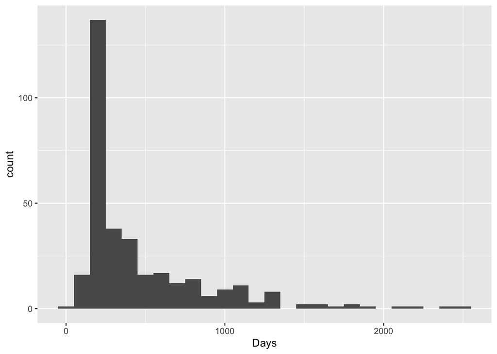

```r
ggplot(vol_data, aes(as.numeric(Days))) + geom_histogram(binwidth = 100) + xlab("Days")
```

These values have a unimodal, right-skewed distribution with several outliers above 1500 days. With a median value of 280 days, reaching these agreements takes quite a bit of time.

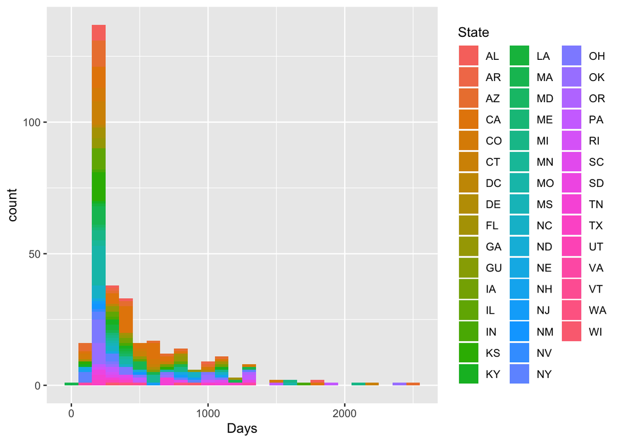

```r
ggplot(vol_data, aes(x = as.numeric(Days), fill = State)) + geom_histogram(binwidth = 100) + xlab("Days")
```

Overlaying the State values onto this histogram, unfortunately, doesn’t reveal any underlying pattern because the number of states (46) is too high.

Now, I want to see how many agreements are in negotiation in a particular month over time. This will require aggregating the data by ReceivedMonthYear and ResolvedMonthYear.

```r
## Get the minimum (earliest) and maximum (latest) Received and Resolved months
minReceived <- min(vol_data$ReceivedMonthYear)
maxReceived <- max(vol_data$ReceivedMonthYear)
minResolved<- min(vol_data$ResolvedMonthYear)
maxResolved <- max(vol_data$ResolvedMonthYear)

## Create a timeline of months from 1 month before minReceived to 1 month after maxResolved
ts <- data.frame(date = seq.Date(from = minReceived - months(1), to = maxResolved + months(1), by = "month"))

## Count the number of complaints received and resolved in a particular month.  Use dummy data frames for summarizing received counts and resolved counts, then merge them into one data frame.
x <- group_by(vol_data, ReceivedMonthYear) %>% summarise(ReceivedCount = n())
y <- group_by(vol_data, ResolvedMonthYear) %>% summarise(ResolvedCount = n())
ts <- merge(ts, y = x, by.x = "date", by.y = "ReceivedMonthYear", all.x = TRUE)
ts <- merge(ts, y = y, by.x = "date", by.y = "ResolvedMonthYear", all.x = TRUE)

## Set all NAs in ReceivedCount and ResolvedCount to 0
ts$ReceivedCount[is.na(ts$ReceivedCount)] <- 0
ts$ResolvedCount[is.na(ts$ResolvedCount)] <- 0

## Calculate the running total for each month.  Note that I assume that the resolved count is subtracted from the running total in the subsequent month.
ts$RunningTotal <- cumsum(ts$ReceivedCount - ifelse(is.na(lag(ts$ResolvedCount)), 0, lag(ts$ResolvedCount)))
```

Let’s look at some summary statistics of the ts (time series) data frame now:

```r
summary(ts)
```

```
##       date            ReceivedCount    ResolvedCount     RunningTotal
##  Min.   :1994-09-01   Min.   : 0.000   Min.   : 0.000   Min.   : 0.00
##  1st Qu.:1999-08-16   1st Qu.: 0.000   1st Qu.: 0.000   1st Qu.: 3.00
##  Median :2004-08-01   Median : 0.000   Median : 0.000   Median : 9.00
##  Mean   :2004-07-31   Mean   : 1.393   Mean   : 1.393   Mean   :22.35
##  3rd Qu.:2009-07-16   3rd Qu.: 2.000   3rd Qu.: 1.000   3rd Qu.:32.50
##  Max.   :2014-07-01   Max.   :14.000   Max.   :12.000   Max.   :95.00
```

ReceivedCount and ResolvedCount look to have a very similar distribution from these statistics. Visualizing them (histograms below) confirms that.

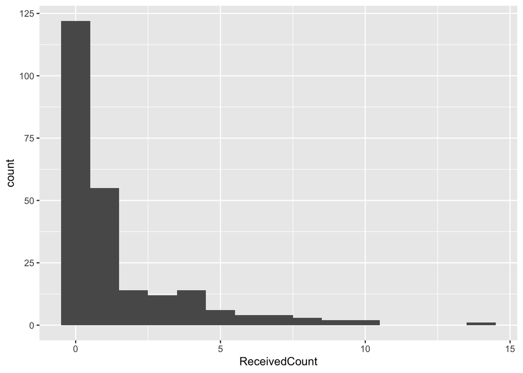

```r
ggplot(ts, aes(ReceivedCount)) + geom_histogram(binwidth = 1)
```

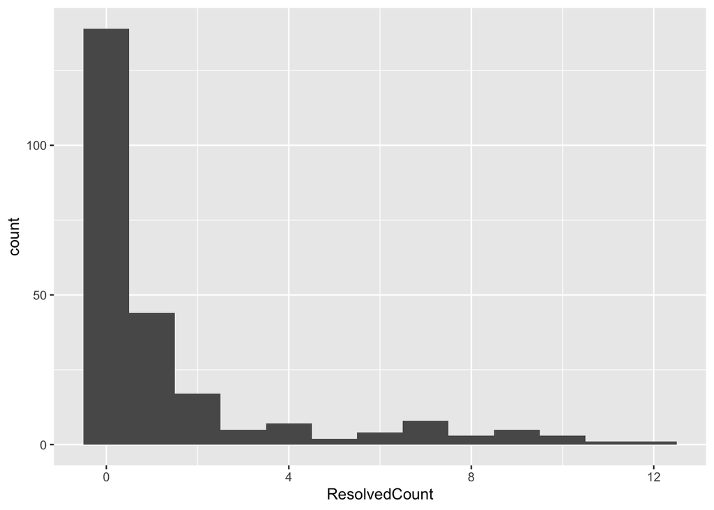

```r
ggplot(ts, aes(ResolvedCount)) + geom_histogram(binwidth = 1)
```

Next is to review the number of agreements by state.

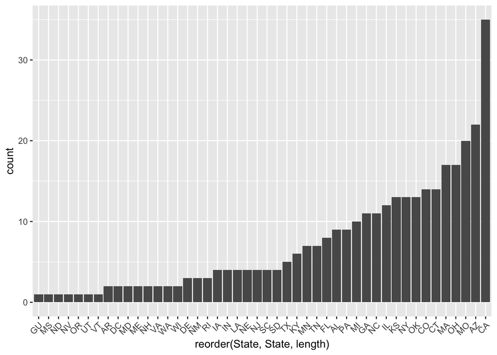

```r
ggplot(vol_data, aes(x = reorder(State, State, length))) + geom_bar() + theme(axis.text.x = element_text(angle = 45, hjust = 1))
```

It makes sense that California has the most number of agreements because it is a very diverse state and is the most populous. Arizona also has a high Hispanic population, though is not that populous. Still, it seems reasonable to have so many agreements. However, the next few states (MO, OH, MA, CT, CO) don’t make as much sense without delving deeper into demographics and population sizes of those states. Another factor may be when the complaints (which generated the agreeements) were filed.

Finally, let’s look at the RunningTotal, which is essentially the number of compliants in progress at any particular time.

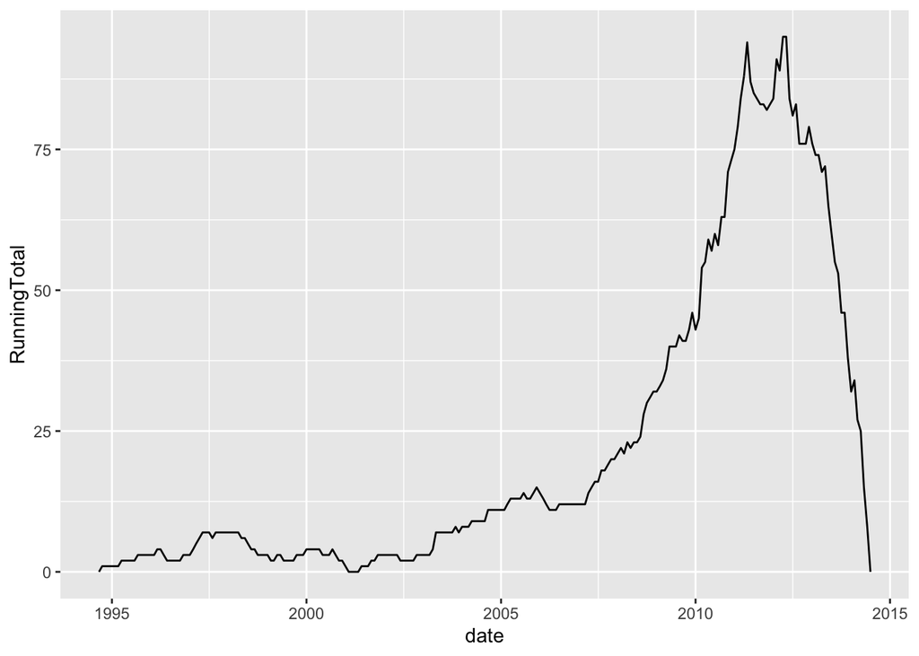

```r
ggplot(ts, aes(x = date, y = RunningTotal)) + geom_line()
```

## invol_data

Let’s review the characteristics of the invol_data set:

```r
str(invol_data)
```

```
## 'data.frame':    769 obs. of  5 variables:
##  $ District.Name: Factor w/ 739 levels "Abbeville 60",..: 1 2 3 4 5 6 7 8 9 10 ...
##  $ City         : Factor w/ 600 levels "","Abbeville",..: 2 3 121 496 6 210 74 7 257 10 ...
##  $ State        : Factor w/ 37 levels "AL","AR","AZ",..: 32 22 16 21 1 9 23 33 34 1 ...
##  $ Year.Lifted  : Factor w/ 49 levels "1967","1969",..: 17 48 14 32 48 4 42 48 35 35 ...
##  $ Year.Placed  : Factor w/ 31 levels "1954","1955",..: 31 16 31 31 10 31 31 13 31 31 ...
```

```r
head(invol_data)
```

```
##          District.Name        City State Year.Lifted Year.Placed
## 1         Abbeville 60   Abbeville    SC        1984         N/A
## 2 Aberdeen School Dist    Aberdeen    MS  STILL OPEN        1969
## 3        Acadia Parish     Crowley    LA        1981         N/A
## 4           Affton 101    St Louis    MO        1999         N/A
## 5       Alabaster City   Alabaster    AL  STILL OPEN        1963
## 6              Alachua Gainesville    FL        1971         N/A
```

```r
summary(invol_data)
```

```
##           District.Name           City         State         Year.Lifted
##  Fayette County  :  3   Indianapolis:  9   AL     :126   STILL OPEN:330
##  Jefferson County:  3   St Louis    :  8   GA     :109   2007      : 38
##  Shelby County   :  3               :  7   MS     : 97   2006      : 36
##  Baldwin County  :  2   Greenville  :  5   TX     : 60   2005      : 31
##  Bibb County     :  2   Abbeville   :  4   LA     : 59   1998      : 29
##  Bradford        :  2   Columbia    :  4   NC     : 35   2003      : 26
##  (Other)         :754   (Other)     :732   (Other):283   (Other)   :279
##   Year.Placed
##  N/A    :462
##  1969   : 73
##  1970   : 46
##  1963   : 39
##  1966   : 32
##  1965   : 23
##  (Other): 94
```

There’s a high proportion of N/As in the Year.Placed column, specifically, 60.1% of the Year.Placed records are ‘N/A’. This makes analysis of how long the mandatory desegration orders have been in effect not representative of the population, so we won’t perform that analysis.

Instead, we’ll only analyze the State and Year.Lifted fields.

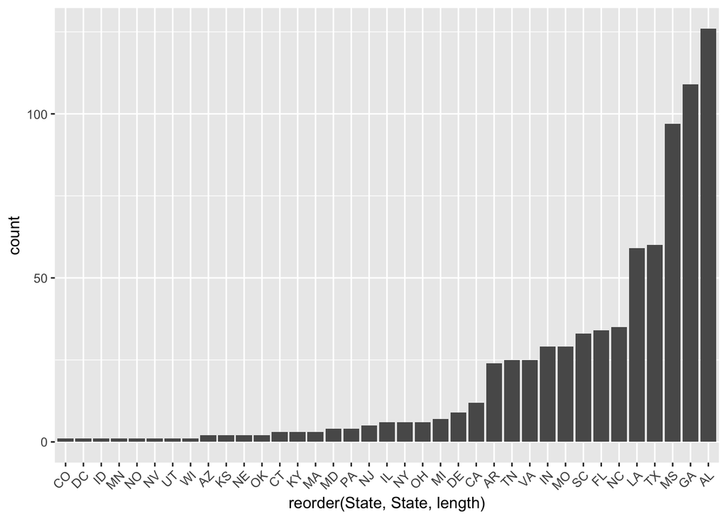

```r
ggplot(invol_data, aes(x = reorder(State, State, length))) + geom_bar() + theme(axis.text.x = element_text(angle = 45, hjust = 1))
```

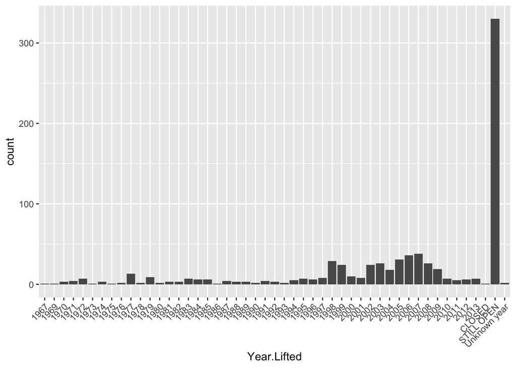

```r
ggplot(invol_data, aes(Year.Lifted)) + geom_bar() + theme(axis.text.x = element_text(angle = 45, hjust = 1))
```

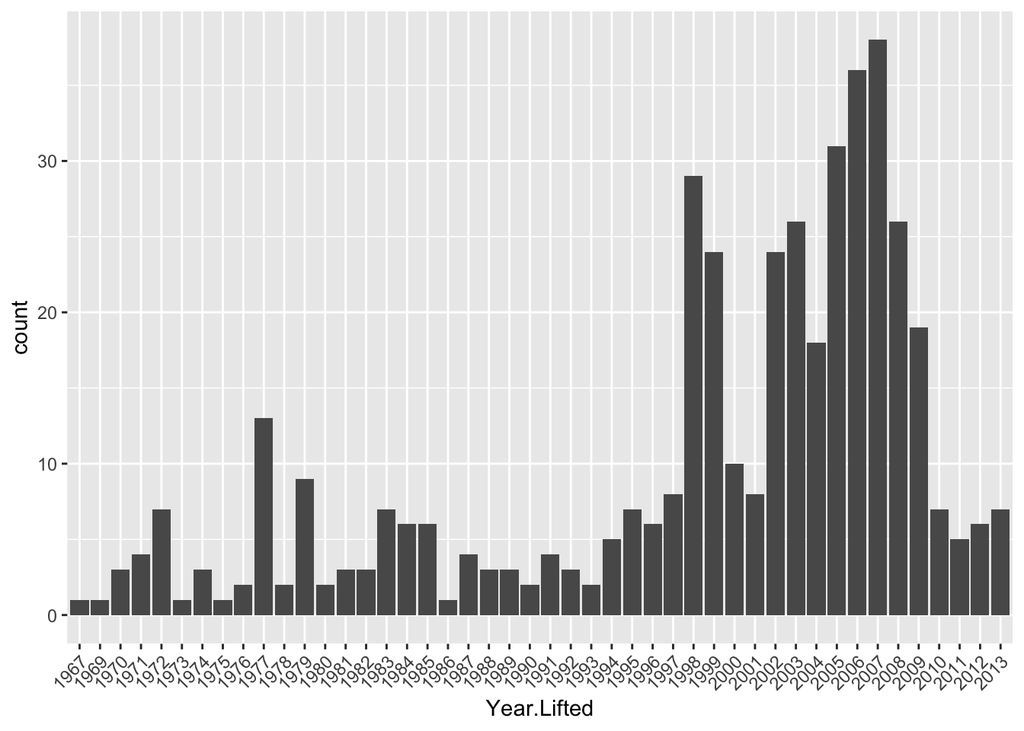

```r
ggplot(invol_data[invol_data$Year.Lifted != "STILL OPEN" & invol_data$Year.Lifted != "Unknown year" & invol_data$Year.Lifted != "CLOSED", ], aes(Year.Lifted)) + geom_bar() + theme(axis.text.x = element_text(angle = 45, hjust = 1))
```

Many of the orders were lifted in the late ’90s and during the 2000s.

## Conclusion

As an exercise in exploratory data analysis using R Markdown, this dataset was simple enough to run through fairly quickly. However, it lacked some important information, specifically a higher percentage of good data in the Year.Placed field of the invol_data dataset (for mandatory desegregation orders). Nevertheless, the data still generated some important insights.

On a technical note, I’d like to figure out how to sort the state charts could be sorted in descending order.